# Classification

Author

Jeffrey Smith

Published

February 24, 2025

**Abstract:**

This is a technical blog post of **both** an HTML file *and* [.qmd file](https://jysmochi.github.io/data_505_hw/classification.qmd) hosted on GitHub pages.

# 1. Setup

**Step Up Code:**

```r
sh <- suppressPackageStartupMessages
sh(library(tidyverse))
sh(library(caret))
sh(library(naivebayes))
sh(library(pROC))
sh(library(thematic))
thematic_rmd(bg = "#111", fg = "#eee", accent = "#eee")
wine <- readRDS(gzcon(url("https://github.com/cd-public/D505/raw/master/dat/pinot.rds")))
```

# 2. Logistic Concepts

Why do we call it Logistic Regression even though we are using the technique for classification?

> We call it Logistic Regression because of the way that this technique works under the hood. Like simple linear regression, this algorithm also uses a regression line to classify data.

# 3. Modeling

We train a logistic regression algorithm to classify a whether a wine comes from Marlborough using:

1. An 80-20 train-test split.
2. Three features engineered from the description
3. 5-fold cross validation.

```r
set.seed(144) # first three digit number in fibonacci sequence
mywine = wine %>%
  mutate(fct_year = factor(year)) %>%
  mutate(mycherry = str_detect(description, "cherry")) %>%
  mutate(mychocolate = str_detect(description, "chocolate")) %>%
  mutate(myearth = str_detect(description, "earth")) %>%
  mutate(marl = as.factor(province == "Marlborough")) %>%
  select(-description, -year, -id, -province)

this_and_that = createDataPartition(mywine$marl, p = 0.80, list = FALSE)
train = mywine[this_and_that,]
test = mywine[-this_and_that,]

fit <- train(marl ~ .,
             data = train,
             trControl = trainControl(method = "cv", number = 5),
             method = "glm",
             family = "binomial")
print(fit)
```

```
Generalized Linear Model

6705 samples
   6 predictor
   2 classes: 'FALSE', 'TRUE'

No pre-processing
Resampling: Cross-Validated (5 fold)
Summary of sample sizes: 5364, 5364, 5363, 5365, 5364
Resampling results:

  Accuracy   Kappa
  0.9722596  0.008919521
```

# 4. Binary vs Other Classification

What is the difference between determining some form of classification through logistic regression versus methods like $K$-NN and Naive Bayes which performed classifications.

> Classification methods such as $K$-NN and Naive Bayes assign data points to their class, whereas logistic regression calculates the probability that a data point belongs to a certain class. A cut-off is assigned for these probabilities where high enough probabilities indicate assignment to said class.

# 5. ROC Curves

We can display an ROC for the model to explain your model’s quality.

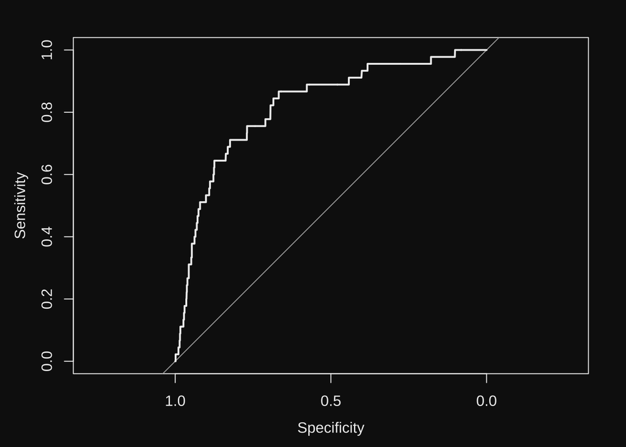

```
Call:
roc.default(response = test$marl, predictor = prob)

Data: prob in 1630 controls (test$marl FALSE) < 45 cases (test$marl TRUE).
Area under the curve: 0.8203
```

```r
prob <- predict(fit, newdata = test, type = "prob")[,2]
myRoc <- roc(test$marl, prob)
print(plot(myRoc))
```

```r
print(auc(myRoc))
```

```
Area under the curve: 0.8203
```

> The sensitivity of a model is a measure of how well the model detects true positives, and the specificity of a model measures how well the model detects false negatives. To interpret this ROC curve, we can simply look at the area under the curve (AUC). If this AUC value is 1, that indicates a perfect model, and if this AUC value is 0.5, that would show that the model is no better than randomly guessing. Following this logic, higher AUC values are better. Here, the AUC value is 0.8203, which isn’t a great.